# Red Wine Quality por Juliano Mendieta

# Dataset

Este conjunto de dados contém 1.599 vinhos tintos com 11 variáveis de propriedades químicas do vinho. Ao menos 3 especialistas em vinhos avaliaram cada vinho, fornecendo uma nota entre 0 (muito ruim) e 10 (muito excelente).

Red Wine Quality é um dataset relacionado a variates do vinho Português “Vinho Verde”. Por questões de privacidade somente os dados de propriedades químicas e e as avaliações dos especialistas estão disponíveis.

### Informação dos atributos:

1. **fixed acidity** -> acidez fixa (ácido tartárico - g/dm³)
2. **volatile acidity** -> acidez volátil (ácido acético - g/dm³)
3. **citric acid** -> acido cítrico (g/dm³)
4. **residual sugar** -> açucar residual (g/dm³)
5. **chlorides** -> cloretos (cloreto de sódio - g/dm³)
6. **free sulfur dioxide** -> dióxido de enxofre livre (mg/dm³)
7. **total sulfur dioxide** -> dióxido de enxofre total (mg/dm³)
8. **density** -> densidade (g/cm³)
9. **pH**
10. **sulphates** -> sulfatos (sulfato de potássio - g/dm³)
11. **alcohol** -> álcool (% por volume)
12. **quality** -> qualidade (nota entre 0 e 10)

**Questão principal**: *Quais propriedades químicas influenciam a qualidade dos vinhos tintos?*

```
##  [1] "fixed.acidity"        "volatile.acidity"     "citric.acid"
##  [4] "residual.sugar"       "chlorides"            "free.sulfur.dioxide"
##  [7] "total.sulfur.dioxide" "density"              "pH"
## [10] "sulphates"            "alcohol"              "quality"
```

```
##  fixed.acidity   volatile.acidity  citric.acid    residual.sugar
##  Min.   : 4.60   Min.   :0.1200   Min.   :0.000   Min.   : 0.900
##  1st Qu.: 7.10   1st Qu.:0.3900   1st Qu.:0.090   1st Qu.: 1.900
##  Median : 7.90   Median :0.5200   Median :0.260   Median : 2.200
##  Mean   : 8.32   Mean   :0.5278   Mean   :0.271   Mean   : 2.539
##  3rd Qu.: 9.20   3rd Qu.:0.6400   3rd Qu.:0.420   3rd Qu.: 2.600
##  Max.   :15.90   Max.   :1.5800   Max.   :1.000   Max.   :15.500
##    chlorides       free.sulfur.dioxide total.sulfur.dioxide
##  Min.   :0.01200   Min.   : 1.00       Min.   :  6.00
##  1st Qu.:0.07000   1st Qu.: 7.00       1st Qu.: 22.00
##  Median :0.07900   Median :14.00       Median : 38.00
##  Mean   :0.08747   Mean   :15.87       Mean   : 46.47
##  3rd Qu.:0.09000   3rd Qu.:21.00       3rd Qu.: 62.00
##  Max.   :0.61100   Max.   :72.00       Max.   :289.00
##     density             pH          sulphates         alcohol
##  Min.   :0.9901   Min.   :2.740   Min.   :0.3300   Min.   : 8.40
##  1st Qu.:0.9956   1st Qu.:3.210   1st Qu.:0.5500   1st Qu.: 9.50
##  Median :0.9968   Median :3.310   Median :0.6200   Median :10.20
##  Mean   :0.9967   Mean   :3.311   Mean   :0.6581   Mean   :10.42
##  3rd Qu.:0.9978   3rd Qu.:3.400   3rd Qu.:0.7300   3rd Qu.:11.10
##  Max.   :1.0037   Max.   :4.010   Max.   :2.0000   Max.   :14.90
##     quality
##  Min.   :3.000
##  1st Qu.:5.000
##  Median :6.000
##  Mean   :5.636
##  3rd Qu.:6.000
##  Max.   :8.000
```

Alguns pontos interessantes até agora:

- Valores de qualidade não possuem entradas entre de 0 a 2 e de 9 a 10!
- Temos uma média e mediana relativamente distantes em *total.sulfur.dioxide*!

# Seção de Gráficos Univariados

## Distribuição das Propriedades Químicas

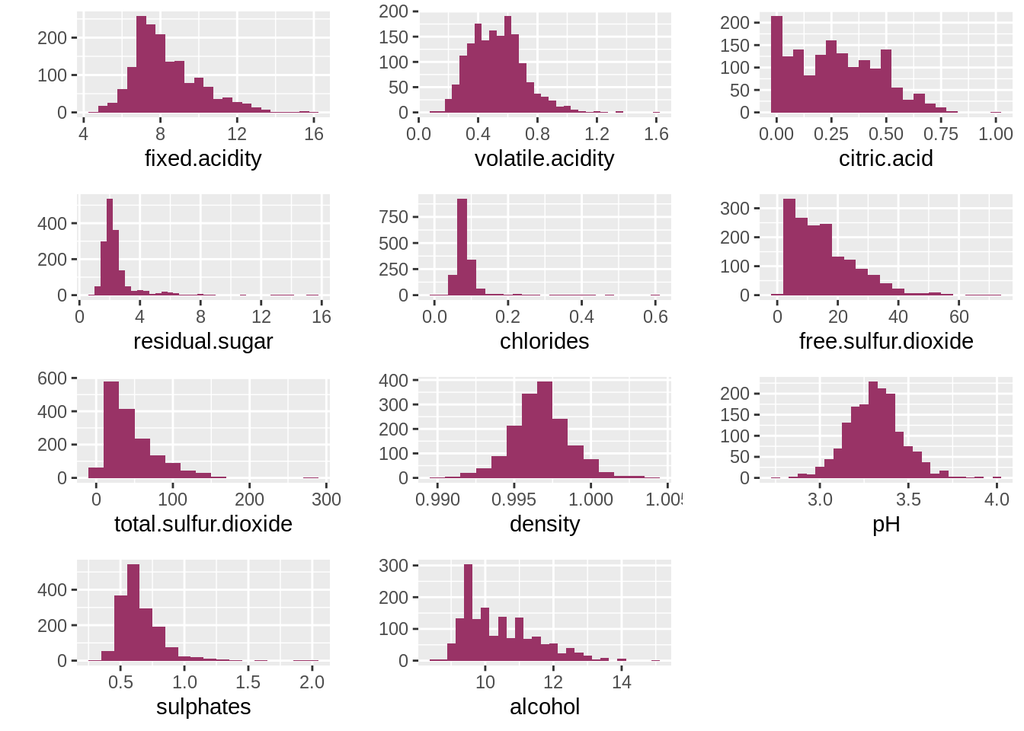

Primeiramente esse gráfico busca entender como estão distribuidas cada propriedade química desse dataset e gerar insights de como transformar os dados para um melhor resultado.

Observações:

- *volatile.acidity, density and PH* possuem uma distribuição **normal**.
- *fixed.acidity, citric.acid, free.sulfur.dioxide, total.sulfur.dioxide,* *sulphates, alcohol* possuem uma distribuição de **assimetria positiva**.
- *residual.sugar, chlorides* possuem uma distribuição de **cauda longa**.

## Distribuição das Propriedades Químicas (Log10)

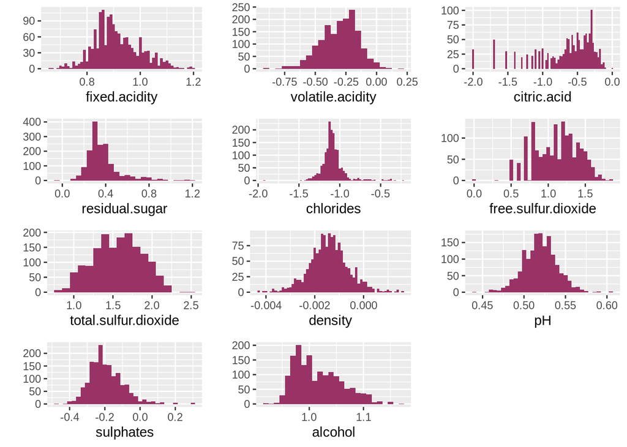

Da mesma maneira, esse gráfico nos mostra a distribuição dos dados após a transformação logarítmica, que busca reduzir o efeito de distribuições enviezadas. Podemos ver que o *sulphates* já se encontra melhor distribuído.

## Distribuição das Propriedades Químicas (Sqrt)

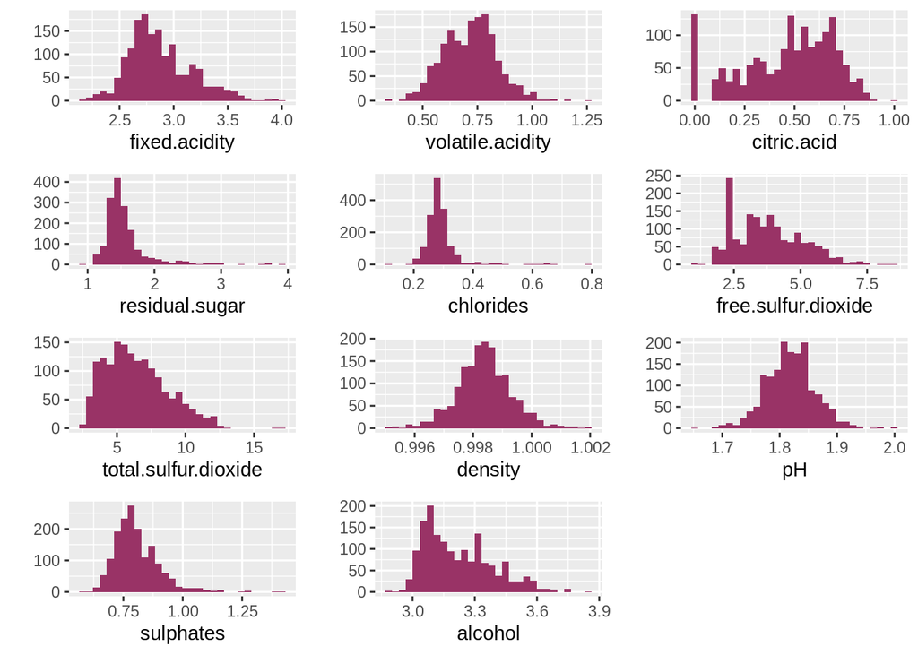

O gráfico aqui nos mostra o resultado da transformação por raíz quadrada, que tem o mesmo objetivo da logarítmica. Foi feita para avaliar se a distribuição ficaria mais normalizada com a mesma.

## Distribuição da Qualidade do Vinho

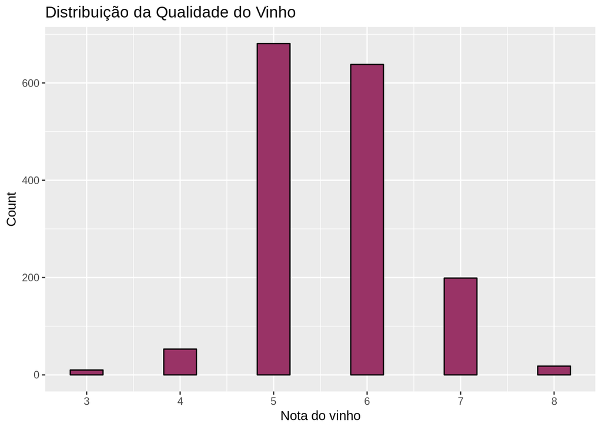

Conforme vimos anteriormente, não existem valores de 0 a 2 e de 9 a 10.

Com esse gráfico podemos ver uma grande concentração dos dados para vinhos com notas 5 e 6.

Podemos dividir as notas de qualidade em 3 níveis para auxiliar em próximas visualizações: **baixa (3-4), média (5-6) e alta (7-8)**.

## Análise da Qualidade do Vinho por Níveis de Qualidade

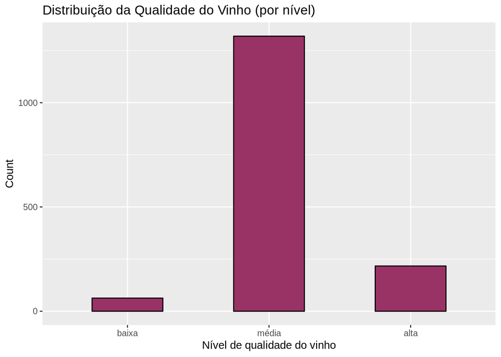

Com nova variável torna-se ainda mais clara o desbalanceamento do dataset, que concentra a maior parte de seus exemplos em vinhos de qualidade média.

# Análise Univariada

### Qual é a estrutura do conjunto de dados?

Um dataframe com 1599 observações e 13 variáveis. Sendo dessas:

- 11 propriedades químicas do vinho.
- 1 nota de qualidade (0, 10) do vinho segundo especialistas.
- 1 nível de qualidade (baixa, média, alta) do vinho. Variável adicionada ao dataframe a partir do agrupamento nota de qualidade.

Outras observações:

- A maior parte dos dados do dataset possuem qualidade com valor de 5 e 6.

### Quais são os principais atributos de interesse deste conjunto de dados?

O principal atributo de interesse nesse conjunto de dados é a nota de qualidade. Queremos analisar a tendência das notas de qualidade com base dos componentes químicos.

### Quais outros atributos você acha que podem lhe auxiliar na investigação destes atributos de interesse?

Com a pouca experiência que tenho com a arte de degustação de vinhos, acredito que os atributos que mais podem impactar a qualidade do mesmo são a quantidade de álcool e o quão ácido o vinho é. São os principais atributos que levo em consideração na hora de avaliar um vinho.

### Você criou novas variáveis a partir dos atributos existentes no conjunto de dados?

Sim, foi criada a variável *quality.level*. Essa variável corresponde a um agrupamento da variável qualidade por “níveis de qualidade”, conforme tabela abaixo.

| Nível de qualidade | Notas |
| --- | --- |
| Baixa | 3, 4 |
| Média | 5, 6 |
| Alta | 7, 8 |

Essa variável foi criada pensando em uma melhor análise visual e se aproveita do fato de grande parte dos dados estarem concentrados nos valores de qualidade 5 e 6.

### Dos atributos investigados, distribuições incomuns foram encontradas? Você aplicou operações nos dados para limpá-los, ajustá-los ou mudar a forma dos dados? Se sim, por quê?

Distribuições incomuns foram encontradas:

- *fixed.acidity, citric.acid, free.sulfur.dioxide, total.sulfur.dioxide,* *sulphates, alcohol* possuem uma distribuição de **assimetria positiva**.
- *residual.sugar, chlorides* possuem uma distribuição de **cauda longa**.

Apliquei transformações logarítmicas e de raiz quadrada para ver se, após isso, as distribuições encontravam-se mais normalizadas. Desse modo, se precisar utilizar alguma dessas variáveis poderei usar essa variável transformada para obter resultados que tragam mais valor real para a análise.

# Seção de Gráficos Bivariados

## Matriz de Correlação de Pearson

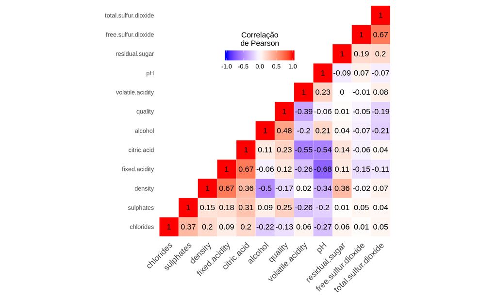

A correlação de Pearson nos permite algumas inferências:

- A qualidade do vinho está negativamente correlacionada com a variável *volatile.acidity* em um valor considerável (-0.39). O que nos leva a inferir que quando a mesma cresce, a qualidade do vinho tende a descer.
- A qualidade do vinho está positivamente correlacionada com a variável *alcohol* em um valor considerável (0.48). O que nos leva a inferir que quando a porcentagem de álcool aumenta, a qualidade do vinho tende a crescer.
- A qualidade do vinho está positivamente correlacionada com as variáveis *sulphates* e *citric.acid* com 0.25 e 0.23 respectivamente. Essas duas variáveis nos fazem inferir que quantidades maiores da mesma tendem a levar a qualidade do vinho a valores maiores, mesmo que com uma importância menor do que *alcohol* e *volatile.acidity*.

## Análise de Correlação - Variáveis Principais

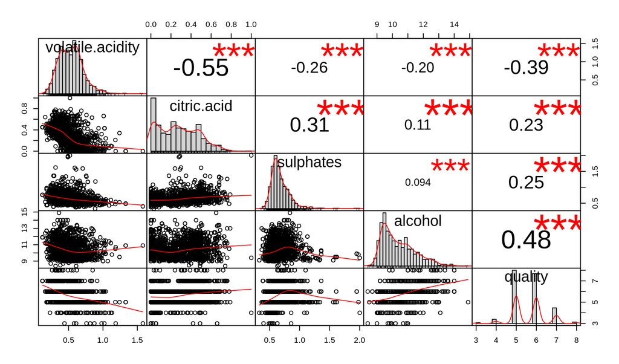

Após avaliar que as variáveis *volatile.acidity*, *citric.acid*, *sulphates* e *alcohol* são as que possuem maior correlação com a qualidade, foi feita uma nova análise de correlação levando em conta somente essas variáveis, para um olhar mais focado e refinado em suas distribuições e correlações.

Com essa nova análise podemos ver que as variáveis *volatile.acidity* e *citric.acid* possuem forte correlação negativa. Como *volatile.acidity* possui a maior correlação com qualidade, manterei somente ela para as próximas análises.

## Importância Relativa das Variáveis na Qualidade

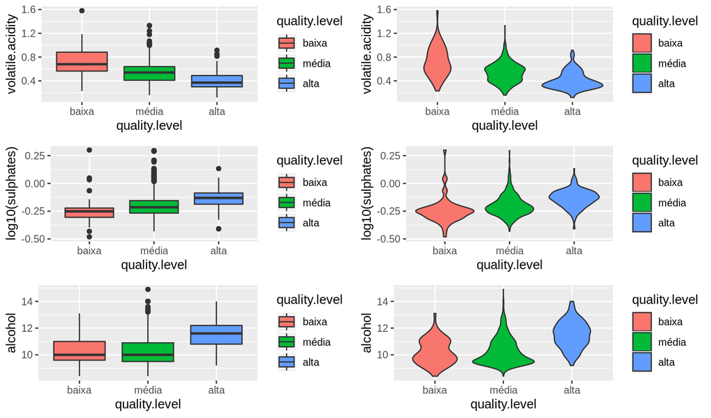

Os gráficos de violino e boxplot reforçam e demonstram as descobertas feitas nas análises anteriores:

Vinhos com notas mais altas possuem valores mais baixos de *volatile.acidity* e valores mais altos de *sulphates* e *alcohol*.

As estatísticas para cada uma das variáveis avaliadas no gráfico acima pode ser vista nas tabelas abaixo.

Estatísticas para **volatile.acidity**:

```
## wQR$quality.level: baixa
##    Min. 1st Qu.  Median    Mean 3rd Qu.    Max.
##  0.2300  0.5650  0.6800  0.7242  0.8825  1.5800
## --------------------------------------------------------
## wQR$quality.level: média
##    Min. 1st Qu.  Median    Mean 3rd Qu.    Max.
##  0.1600  0.4100  0.5400  0.5386  0.6400  1.3300
## --------------------------------------------------------
## wQR$quality.level: alta
##    Min. 1st Qu.  Median    Mean 3rd Qu.    Max.
##  0.1200  0.3000  0.3700  0.4055  0.4900  0.9150
```

Estatísticas para **sulphates**:

```
## wQR$quality.level: baixa
##    Min. 1st Qu.  Median    Mean 3rd Qu.    Max.
## -0.4815 -0.3054 -0.2518 -0.2456 -0.2218  0.3010
## --------------------------------------------------------
## wQR$quality.level: média
##    Min. 1st Qu.  Median    Mean 3rd Qu.    Max.
## -0.4318 -0.2676 -0.2147 -0.2004 -0.1549  0.2967
## --------------------------------------------------------
## wQR$quality.level: alta
##     Min.  1st Qu.   Median     Mean  3rd Qu.     Max.
## -0.40894 -0.18709 -0.13077 -0.13572 -0.08619  0.13354
```

Estatísticas para **alcohol**:

```
## wQR$quality.level: baixa
##    Min. 1st Qu.  Median    Mean 3rd Qu.    Max.
##    8.40    9.60   10.00   10.22   11.00   13.10
## --------------------------------------------------------
## wQR$quality.level: média
##    Min. 1st Qu.  Median    Mean 3rd Qu.    Max.
##    8.40    9.50   10.00   10.25   10.90   14.90
## --------------------------------------------------------
## wQR$quality.level: alta
##    Min. 1st Qu.  Median    Mean 3rd Qu.    Max.
##    9.20   10.80   11.60   11.52   12.20   14.00
```

# Análise Bivariada

### Discuta sobre alguns dos relacionamentos observados nesta parte da investigação. Como os atributos de interesse variaram no conjunto de dados?

- A qualidade do vinho está negativamente correlacionada com a variável *volatile.acidity* em um valor considerável (-0.39). O que nos leva a inferir que quando a mesma cresce, a qualidade do vinho tende a descer.
- A qualidade do vinho está positivamente correlacionada com a variável *alcohol* em um valor considerável (0.48). O que nos leva a inferir que quando a porcentagem de álcool aumenta, a qualidade do vinho tende a crescer.
- A qualidade do vinho está positivamente correlacionada com as variáveis *sulphates* e *citric.acid* com 0.25 e 0.23 respectivamente. Essas duas variáveis nos fazem inferir que quantidades maiores da mesma tendem a levar a qualidade do vinho a valores maiores, mesmo que com uma importância menor do que *alcohol* e *volatile.acidity*.

### Você observou algum relacionamento interessante entre os outros atributos (os que não são de interesse)?

Outros relacionamentos interessantes são:

- As variáveis *volatile.acidity* e *citric.acid* possuem forte correlação negativa.
- As variáveis *pH* e *citric.acid*/*fixed.acidity* possuem forte correlação negativa. Isso se deve ao fato de que ácidos possuem menores valores de pH.
- As variáveis *density* e *fixed.acidity* possuem forte correlação positiva. Vinhos que possuem uma acidez fixa são mais densos e mais difíceis de evaporar.

### Qual foi o relacionamento mais forte encontrado?

O relacionamento com qualidade mais forte encontrado foi a porcentagem de álcool do vinho, que com valores mais elevados tende a ter uma maior nota.

# Seção de Gráficos Multivariados

## Importância Relativa Combinada de **sulphates** e **alcohol**

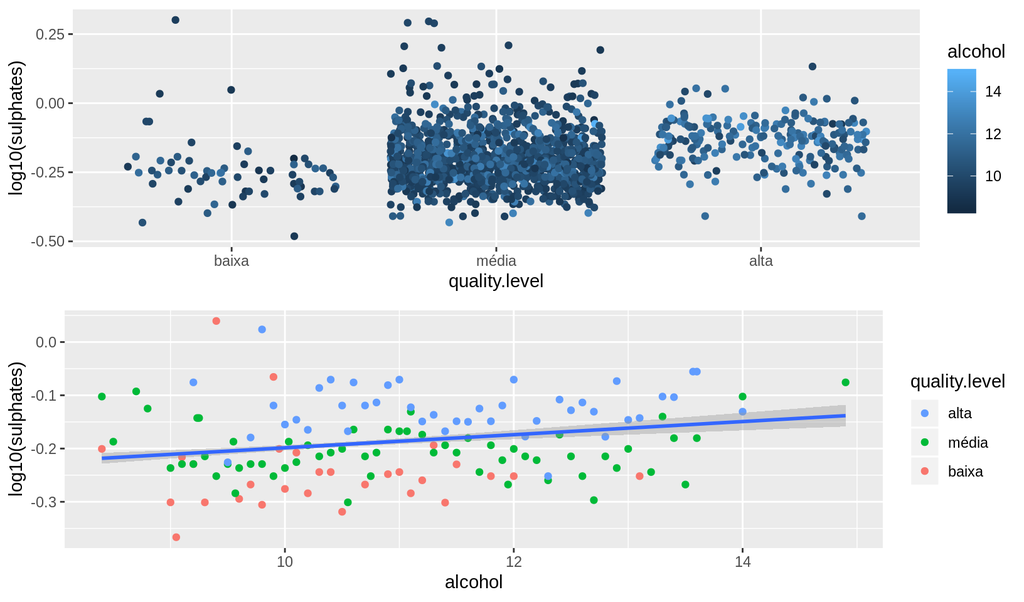

Com os gráficos acima podemos ver que vinhos com uma qualidade mais alta possuem um conjunto de valores mais altos de álcool e sulfatos.

## Importância Relativa Combinada de **volatile.acidity** e **alcohol**

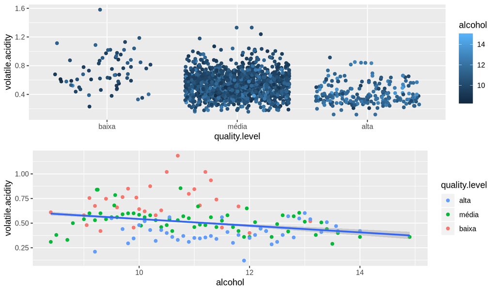

Com os gráficos acima podemos ver que vinhos com uma qualidade mais alta possuem uma combinação de valores mais altos de álcool e valores pequenos de acidez volátil.

## Importância Relativa Combinada de **volatile.acidity** e **sulphates**

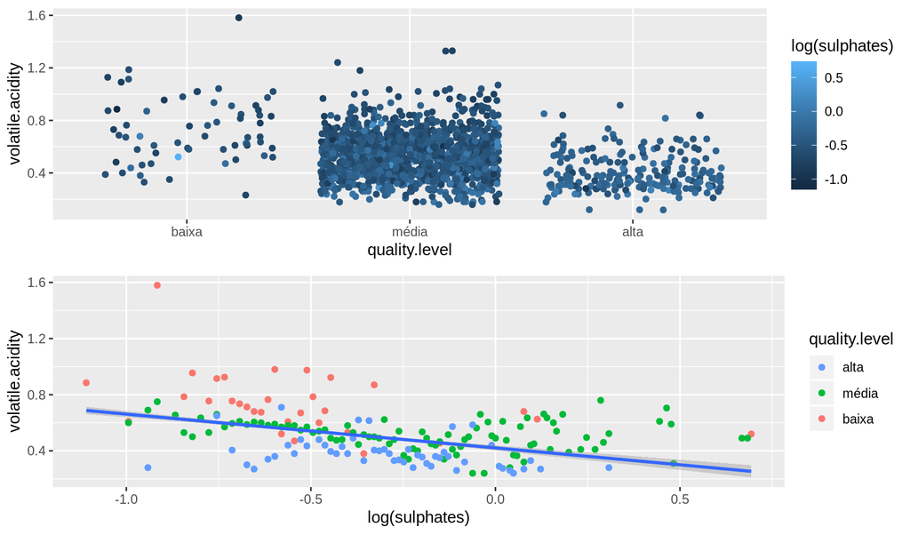

Com os gráficos acima podemos ver que vinhos com uma qualidade mais alta possuem uma combinação de valores mais altos de sulfatos e valores pequenos de acidez volátil. Podemos ver que ao aumentar os sulfatos, diminuímos a acidez volátil.

## Importância Relativa de **volatile.acidity**, **sulphates** e **alcohol**

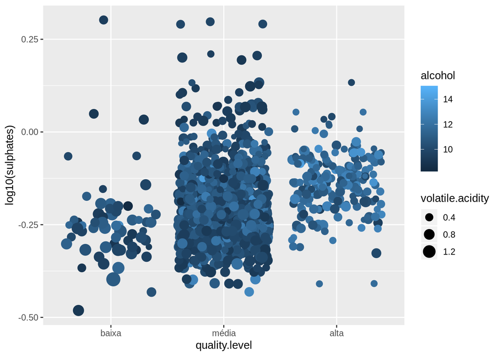

Juntando todas as análises anteriores, temos um gráfico que comprova a teoria criada durante outras análises de que vinhos com maio qualidade são os que possuem:

- Valores **mais altos** de Álcool;
- Valores **mais altos** de Sulfatos; e
- Valores **mais baixos** de Acidez Volátil.

# Análise Multivariada

### Discuta sobre os relacionamentos observados nesta parte da investigação. Quais atributos que fortaleceram os demais na observação das variáveis de interesse?

Analisando as variáveis mais correlacionadas a qualidade, chegamos a conclusão de que para obtermos vinhos de qualidade maior, os atributos que mais fortalecem são:

- **Álcool** com valores **mais altos**;
- **Sulfatos** com valores **mais altos**; e
- **Acidez Volátil** com valores **mais baixos**.

### Interações surpreendentes e/ou interessantes foram encontradas entre os atributos?

Foi possível perceber que ao aumentar a quantidade de sulfatos no vinho a acidez volátil diminuiu e, como consequência, a qualidade do vinho aumenta.

# Gráficos Finais e Sumário

### Primeiro Gráfico

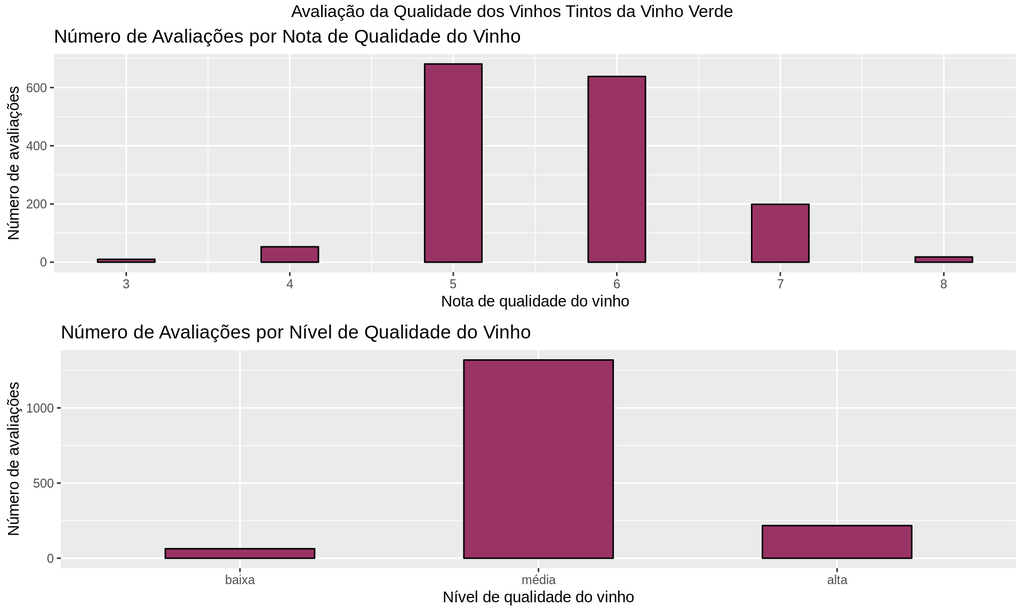

### Descrição do Primeiro Gráfico

Para cada entrada no conjunto de dados ao menos 3 especialistas em vinhos avaliaram cada vinho, fornecendo uma nota entre 0 (muito ruim) e 10 (muito excelente).

A distribuição das notas de qualidade do vinho estão extremamente concentradas nos valores 5 e 6, categorizadas como nível médio de qualidade. Além disso, não existem vinhos que foram avaliados com notas entre de 0 a 2 e nem de 9 a 10.

Para facilitar a análise e visualização as notas foram agrupadas da seguinte forma:

| Nível de qualidade | Notas |
| --- | --- |
| Baixa | 3, 4 |
| Média | 5, 6 |
| Alta | 7, 8 |

### Segundo Gráfico

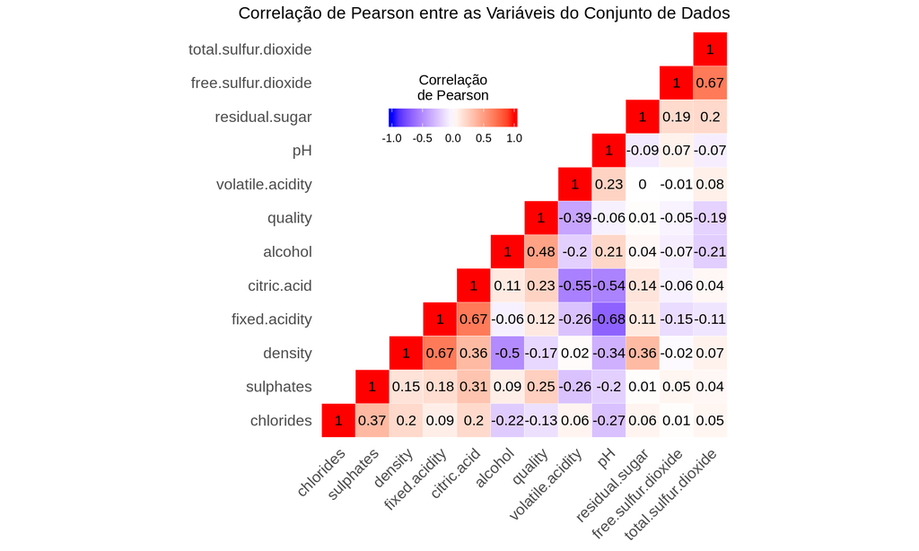

### Descrição do Segundo Gráfico

A correlação de Pearson nos permite algumas inferências:

- A qualidade do vinho está negativamente correlacionada com a variável *volatile.acidity* em um valor considerável (-0.39). O que nos leva a inferir que quando a mesma cresce, a qualidade do vinho tende a descer.
- A qualidade do vinho está positivamente correlacionada com a variável *alcohol* em um valor considerável (0.48). O que nos leva a inferir que quando a porcentagem de álcool aumenta, a qualidade do vinho tende a crescer.
- A qualidade do vinho está positivamente correlacionada com as variáveis *sulphates* e *citric.acid* com 0.25 e 0.23 respectivamente. Essas duas variáveis nos fazem inferir que quantidades maiores da mesma tendem a levar a qualidade do vinho a valores maiores, mesmo que com uma importância menor do que *alcohol* e *volatile.acidity*.

### Terceiro Gráfico

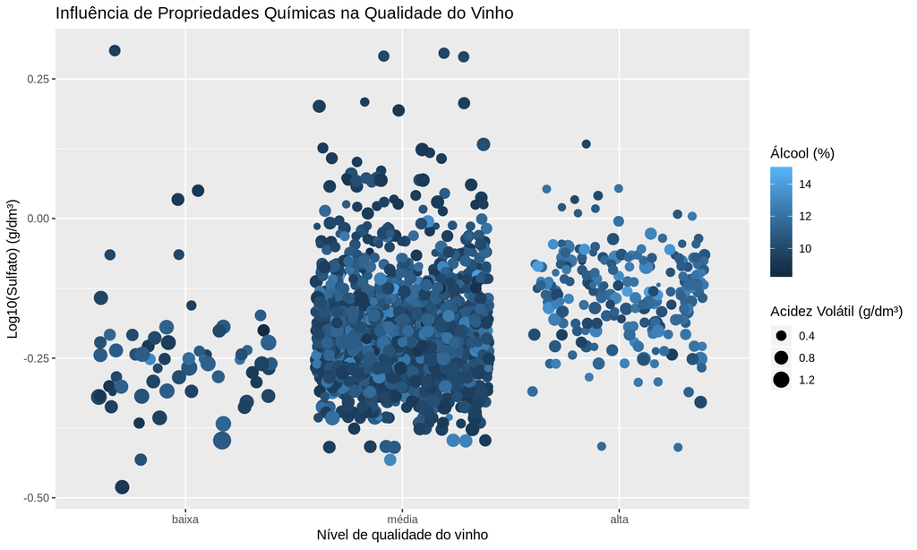

### Descrição do Terceiro Gráfico

Analisando as variáveis mais correlacionadas a qualidade, conclui-se vinhos de qualidade maior possuem as seguintes propriedades:

- **Álcool** com valores **mais altos**;
- **Sulfatos** com valores **mais altos**; e
- **Acidez Volátil** com valores **mais baixos**.

# Reflexão

Este conjunto de dados contém 1.599 vinhos tintos com 11 variáveis de propriedades químicas do vinho. Ao menos 3 especialistas em vinhos avaliaram cada vinho, fornecendo uma nota entre 0 (muito ruim) e 10 (muito excelente). Nosso objetivo neste projeto é identificar a correlação entre as variáveis e a qualidade do vinho.

Minha maior dificuldade foi me familiarizar com como as coisas acontecem no R, principalmente nesse formato de RMarkdown. Estou acostumado a usar Python e Jupyter e no próprio RStudio tive que dar uma relembrada. Além disso, nas análises foi dificil encontrar alguma variável que fosse a principal, como acontece no famoso exemplo de análise de diamantes. Por último, o desbalanceamento da variável alvo (quality) pode ter empobrecido a análise, uma vez que seria interessante ter amostras mais balanceadas para obter melhores resultados.

As análises começaram a ficar mais promissoras quando visualizações da correlação entre os dados foram sendo geradas, uma vez que foi possível não só identificar a correlação entre as váriaveis e a qualidade do vinho mas também qual é a correlação entre as próprias variáveis. As variáveis com maior correlação com a qualidade do vinho foram:

| Variável | Correlação com Qualidade |
| --- | --- |
| *volatile.acidity* | -0.39 |
| *alcohol* | 0.48 |
| *sulphates* | 0.25 |
| *citric.acid* | 0.23 |

Essa análise poderia ser enriquecida através do fornecimento de mais dados com avaliações que tornassem mais balanceado a variável de qualidade. Além disso, outras variáveis poderiam ser adicionadas para refinar a mesma, como por exemplo o tipo da uva utilizado no processo de criação do vinho. Uma possível abordagem também é aplicar técnicas de aprendizado de máquina não-supervisionado como K-means para obter novos insights e até quem sabe criar um modelo de predição para avaliar a qualidade de novos vinhos.

# Referências

[1] http://www.sthda.com/english/wiki/ggplot2-quick-correlation-matrix-heatmap-r-software-and-data-visualization

[2] https://web.stanford.edu/class/bios221/labs/multivariate/lab_5_multivariate.html